# Laboratorium TEXT - laboratorium 9

Eksploracja tekstu i wyszukiwanie informacji w mediach społecznościowych

LABORATORIUM 9

- Model word2vec
- Model GloVe

#### **Model word2vec**

Jednym z częstych zagadnień związanych z text mining jest budowa tzw. *word embedding*, czyli sposobu reprezentacji wyrazów w postaci liczbowej. W pewien sposób mówliśmy już o tym, kiedy rozpatrywaliśmy **model przestrzeni wektorowej** - jest to jednak bardzo ograniczona rezprezentacja.

**Semantyka dystrybucyjna** znalazła w ostatnich latach szerokie zastosowanie w rozwiązywaniu szeregu zadań związanych z przetwarzaniem języka naturalnego. U jej podstaw leży hipoteza, że słowa występujące w podobnych kontekstach w dużych zbiorach danych tekstowych mają **podobne znaczenie**. Znaczenia słów reprezentowane są przez wektory liczbowe.

Jednym z bardziej popularnych przykładów, należącym do tej grupy metod jest **word2vec**, stworzony przez Tomasa Mikolova z Google ok. 5 lat temu. Podejście to może wykorzystywać dwie różne techniki: **CBOW** - Continuous Bag of Words oraz **Skip-Gram**. Teoretycznie metody są algorytmicznie identyczne, oprócz tego, że CBOW przewiduje kluczowe słowo na podstawie kontekstu np. ``cat sits on the **mat**'', a Skip-Gram odwrotnie. Word2vec używa sieci neuronowej z pojedynczą warstwą jako podstawowej architektury, ale jako ogólny wskaźnik używane jest po prostu prawdopodobieństwo $p(w_t | h)$ słowa $w_t$ pod warunkiem historii (otoczenia) $h$, które jest wyznaczane przy użyciu metody największej wiarygodności.

#### **Model GloVe**

GloVe, czyli **Global Vectors for Word Representation** jest datującą się na rok 2014 techniką zaproponowaną przez naukowców ze Stanford University i opierającą się na następującym algorytmie:

- wykonaj statystykę współwystepowania słów i zapisz ją w postaci macierzy $\mathbf{X}$; zwykle korpus jest skanowany w taki sposób, że szukmay słów kontekstowych w pewnym oknie zarówno przed jak i po interesującym nas słowie; zwykle też dalsze słowa wchodzą z mniejszą wagą np. $w = 1/\text{przesunięcie}$
- zdefiniuj więzy dla każdej pary słów występującej w macierzy $\mathbf{X}$ jako $\mathbf{w}_i^T \mathbf{w}_j + b_i + b = \log X_{ij}$, gdzie $\mathbf{w}_i$ to wektor głównego słowa, a $\mathbf{w}_j$ to wektor słowa z kontekstu, natomiast $b_i$, $b_j$ to skalary
- zdefinuj fukcję kosztu $J = \sum\limits_{i=1}^V\sum\limits_{j=1}^V f(X_{ij})(\mathbf{w}_i^T \mathbf{w}_j + b_i + b - \log X_{ij})^2$,

przy czym $f(X_{ij})$ jest pewną funkcją ważącą, zapobiegającą uczeniu się jedynie od najczęściej wystepujących słów. Funkcja zostało zaproponowana jako $f(X_{ij}) = (X_{ij} / x_{max})^{\alpha}$ dla $X_{ij} < x_{max}$ i $f(X_{ij})=1$ w przeciwnym razie.

Rozpoczynamy od zainstalowania pakietu **text2vec** (co może trochę potrwać), a następnie pobiramy plik potrzebny do analiz - uwaga, dane mają ok. 100MB!

```r
# PRZYKŁAD 9.1

library(text2vec)
file.name <- "http://www.if.pw.edu.pl/~julas/TEXT/lab/text8"
file.in <- readLines(file.name, n = 1, warn = FALSE)
```

```r
# PRZYKŁAD 9.2

tokens <- space_tokenizer(file.in)
tokens[[1]][1:10]
```

```
##  [1] ""           "anarchism"  "originated" "as"         "a"
##  [6] "term"       "of"         "abuse"      "first"      "used"
```

```r
it <- itoken(tokens, progressbar = FALSE)
vocab <- create_vocabulary(it)
vocab
```

```
## Number of docs: 1
## 0 stopwords:  ...
## ngram_min = 1; ngram_max = 1
## Vocabulary:
##               term term_count doc_count
##      1:   piagarmi          1         1
##      2: manganiyar          1         1
##      3:      yavne          1         1
##      4:  aroostock          1         1
##      5: stollwerck          1         1
##     ---
## 253850:         in     372201         1
## 253851:        one     411764         1
## 253852:        and     416629         1
## 253853:         of     593677         1
## 253854:        the    1061396         1
```

```r
vocab <- prune_vocabulary(vocab, term_count_min = 5L)
```

Kolejnym krokiem jest stworzenie macierzy współwystępowania słów, opartej na wspomniane wcześniej ruchome okno - wartośc wynosi 5, co oznacza, że wejdzie do niego po 5 słów z lewej i prawej strony wyrazu.

```r
# PRZYKŁAD 9.3
vectorizer <- vocab_vectorizer(vocab)
tcm <- create_tcm(it, vectorizer, skip_grams_window = 5L)
options(max.print = 1000)
tcm
```

```
## 71290 x 71290 sparse Matrix of class "dgTMatrix"
```

```
##    [[ suppressing 29 column names 'kentauros', 'tornatore', 'phantastica' ... ]]
##    [[ suppressing 29 column names 'kentauros', 'tornatore', 'phantastica' ... ]]
```

[output not shown]

```
##    [[ suppressing 29 column names 'kentauros', 'tornatore', 'phantastica' ... ]]
```

```
##
## three . . . . . . . . . . . . . . . . . . . . . . . . . . . . . ......
## five  . . . . . . . . . . . . . . . . . . . . . . . . . . . . . ......
## s     . . . . . . . . . . . . . . . . . . . . . . . . . . . . . ......
## for   . . . . . . . . . . . . . . . . . . . . . . . . . . . . . ......
## eight . . . . . . . . . . . . . . . . . . . . . . . . . . . . . ......
## as    . . . . . . . . . . . . . . . . . . . . . . . . . . . . . ......
## is    . . . . . . . . . . . . . . . . . . . . . . . . . . . . . ......
## two   . . . . . . . . . . . . . . . . . . . . . . . . . . . . . ......
## nine  . . . . . . . . . . . . . . . . . . . . . . . . . . . . . ......
## zero  . . . . . . . . . . . . . . . . . . . . . . . . . . . . . ......
## to    . . . . . . . . . . . . . . . . . . . . . . . . . . . . . ......
## a     . . . . . . . . . . . . . . . . . . . . . . . . . . . . . ......
## in    . . . . . . . . . . . . . . . . . . . . . . . . . . . . . ......
## one   . . . . . . . . . . . . . . . . . . . . . . . . . . . . . ......
## and   . . . . . . . . . . . . . . . . . . . . . . . . . . . . . ......
## of    . . . . . . . . . . . . . . . . . . . . . . . . . . . . . ......
## the   . . . . . . . . . . . . . . . . . . . . . . . . . . . . . ......
```

Wreszcie przechodzimy do samego uruchomienia algorytmu, ustawiając rozmiar wektora na 50 elementów

```r
# PRZYKŁAD 9.4

glove_model <- GlobalVectors$new(word_vectors_size = 50, vocabulary = vocab, x_max = 10)
words_main <- glove_model$fit_transform(tcm, n_iter = 10, convergence_tol = 0.01)
```

```
## INFO [2019-01-07 06:23:09] 2019-01-07 06:23:09 - epoch 1, expected cost 0.0880
## INFO [2019-01-07 06:23:24] 2019-01-07 06:23:24 - epoch 2, expected cost 0.0614
## INFO [2019-01-07 06:23:39] 2019-01-07 06:23:39 - epoch 3, expected cost 0.0542
## INFO [2019-01-07 06:23:54] 2019-01-07 06:23:54 - epoch 4, expected cost 0.0502
## INFO [2019-01-07 06:24:11] 2019-01-07 06:24:11 - epoch 5, expected cost 0.0477
## INFO [2019-01-07 06:24:28] 2019-01-07 06:24:28 - epoch 6, expected cost 0.0459
## INFO [2019-01-07 06:24:44] 2019-01-07 06:24:44 - epoch 7, expected cost 0.0445
## INFO [2019-01-07 06:24:59] 2019-01-07 06:24:59 - epoch 8, expected cost 0.0434
## INFO [2019-01-07 06:25:15] 2019-01-07 06:25:15 - epoch 9, expected cost 0.0425
## INFO [2019-01-07 06:25:30] 2019-01-07 06:25:30 - epoch 10, expected cost 0.0418
```

Na wyjściu otrzymujemy tak naprawdę dwa wektory $\mathbf{w}_i$ oraz $\mathbf{w}_j$ - teoretycznie powinny byc symetryczne. W praktyce wykorzystuje się średnią lub ich sumę.

```r
# PRZYKŁAD 9.5

words_components <- glove_model$components
W <- words_main + t(words_components)
options(max.print = 1000)
round(W, 3)
```

[output not shown]

[output cut: 135 more lines]

```
## pommern                       -0.168 -0.548
## iconodules                     0.006 -0.609
## palas                          0.025  0.497
## splinters                      0.071  0.283
## nears                         -0.192  0.438
## cashed                         0.135  0.006
## dimasi                         0.030 -0.156
## yisra                          0.383  0.142
## mistranslated                  0.560 -0.214
## adenocarcinoma                -0.495 -0.017
## cheetham                       0.202 -0.011
## cowbell                        0.401  0.498
## wallerstein                    0.461 -1.009
## bluie                         -0.314 -0.174
##  [ reached getOption("max.print") -- omitted 71270 rows ]
```

W tym momencie dysponujemy już w pełni nauczonym modelem, czyli reprezentacją słów w pewnej 50-wymiarowej przestrzeni. Oczywiście najprostsza rzeczą jest po prostu podanie konkretnego słowa i wypisanie podobieństwa do innych wyrazów, korzystając z cosinusa podobieństwa jako miary.

```r
# PRZYKŁAD 9.6

query <- W["student", , drop = FALSE]
cos_sim <- sim2(x = W, y = query, method = "cosine", norm = "l2")
head(sort(cos_sim[,1], decreasing = T))
```

```
##       student      students        school      graduate undergraduate
##     1.0000000     0.7621514     0.7508940     0.7284443     0.7018185
##       teacher
##     0.6861288
```

```r
# PRZYKŁAD 9.7

query <- W["poland", , drop = FALSE]
cos_sim <- sim2(x = W, y = query, method = "cosine", norm = "l2")
head(sort(cos_sim[,1], decreasing = T))
```

```
##    poland    russia   hungary   finland     spain     italy
## 1.0000000 0.7979293 0.7544698 0.7481203 0.7429340 0.7403539
```

Jak widać, można w ten sposób otrzymać również zależności geograficzne. Ciekawą cechą tego typu modeli jest to, że skoro operujemy w pewnej przestrzni wektorowej, to w pewnien sposób możemy oczekiwać, że będzie tam działać zykła arytmatyka wektorowa. W szczególności dodawanie i odejmowanie może doprowadzić do ciekawych wyników:

```r
# PRZYKŁAD 9.8

query <- W["paris", , drop = FALSE] - W["france", , drop = FALSE] + W["germany", , drop = FALSE]
cos_sim <- sim2(x = W, y = query, method = "cosine", norm = "l2")
head(sort(cos_sim[,1], decreasing = T))
```

```
##    berlin     paris    munich   germany   leipzig   dresden
## 0.7578314 0.7458624 0.6459617 0.6394657 0.5938925 0.5883877
```

```r
# PRZYKŁAD 9.9

query <- W["man", , drop = FALSE] - W["he", , drop = FALSE] + W["she", , drop = FALSE]
cos_sim <- sim2(x = W, y = query, method = "cosine", norm = "l2")
head(sort(cos_sim[,1], decreasing = T))
```

```
##       man     woman beautiful        my      girl     child
## 0.8457696 0.8144908 0.6523653 0.6342506 0.6299519 0.6100867
```

I wreszcie chyba najciekawsza cecha, tzw. regularność lingwistyczna. Okazuje się, że tego typu modele zanurzeniowe mogą służyć do wizualizacji pewnych reguł gramatycznych, np. związanych z częsciami mowy etc. Ponieważ pracujemy na 50-wymiarowej przestrzeni, aby wykonac sensowne wykresy musimy wykorzystać metodę skalowania wielowymiarowego.

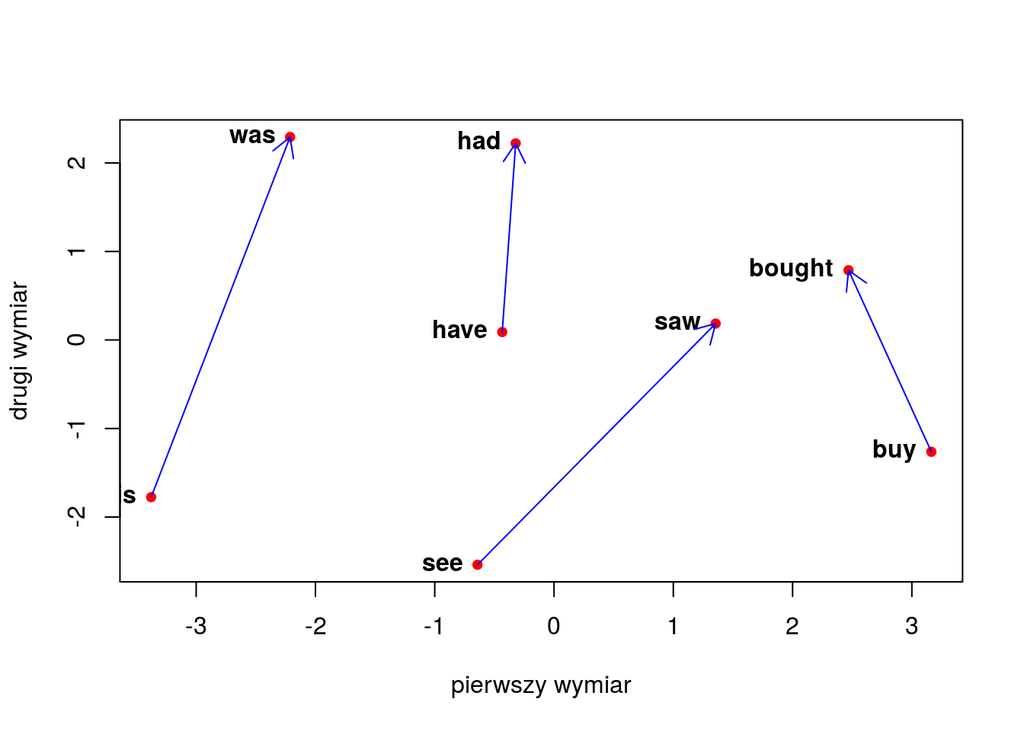

```r
# PRZYKŁAD 9.10

q <- c("see", "saw", "have", "had", "is", "was", "buy", "bought")
z <- cmdscale(dist(W[q,]))
plot(z, pch = 19, cex = 0.8, col = "red", xlab = "pierwszy wymiar", ylab = "drugi wymiar")
text(z, labels = q, pos = 2, font = 2)
invisible(sapply(seq(1, nrow(z) - 1, 2), function(i) arrows(z[i,1],z[i,2],z[i+1,1],z[i+1,2], length = 0.15, col = "blue")))
```

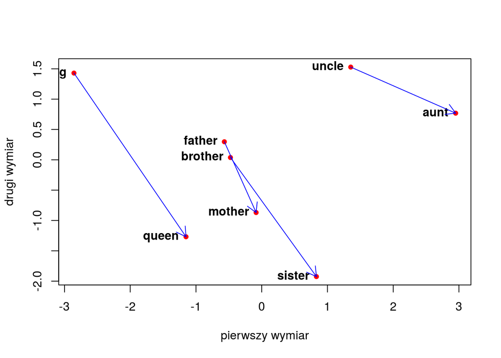

```r
# PRZYKŁAD 9.11

q <- c("king", "queen", "father", "mother", "brother", "sister", "uncle", "aunt")
z <- cmdscale(dist(W[q,]))
plot(z, pch = 19, cex = 0.8, col = "red", xlab = "pierwszy wymiar", ylab = "drugi wymiar")
text(z, labels = q, pos = 2, font = 2)
invisible(sapply(seq(1, nrow(z) - 1, 2), function(i) arrows(z[i,1],z[i,2],z[i+1,1],z[i+1,2], length = 0.15, col = "blue")))
```

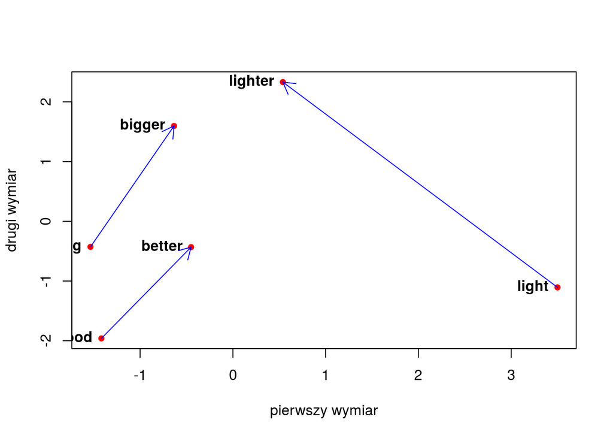

```r
# PRZYKŁAD 9.12

q <- c("good", "better", "big", "bigger", "light", "lighter")
z <- cmdscale(dist(W[q,]))
plot(z, pch = 19, cex = 0.8, col = "red", xlab = "pierwszy wymiar", ylab = "drugi wymiar")
text(z, labels = q, pos = 2, font = 2)
invisible(sapply(seq(1, nrow(z) - 1, 2), function(i) arrows(z[i,1],z[i,2],z[i+1,1],z[i+1,2], length = 0.15, col = "blue")))
```